# Midterm

Robin Jones

2023-05-03

## Question 1

The following code calculates the mean gene and protein expression for chimpanzee(chimp) and human for each gene in datasets 143 and 159. The mean chimp gene mRNA and protein for each gene are then plotted against the mean human gene mRNA and protein for each gene. This is done for both data sets. After inspecting these scatter plots, one can see that there is a possible positive relationship between the expression of chimp mRNA levels and human mRNA levels such that it appears that genes expressed at a lower level in chimp are also expressed at a lower level in human. This appears to be true at higher levels of expression as well. However, when looking at protein expression in the two organisms, it appears that there could be a negative linear relationship between amount of protein produced in chimps and humans, but this is not as obvious as with mRNA.

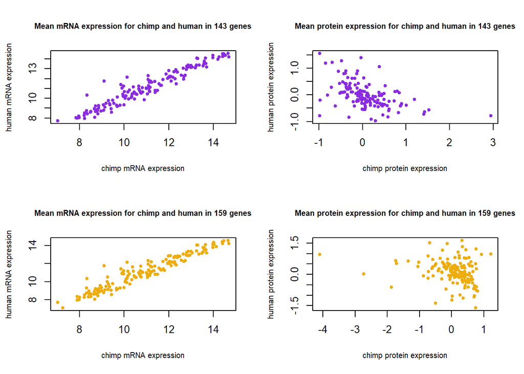

```r
#load data and save, get mean expression for each gene mRNA level and protein level for chimp and human for both data sets
r.143<-read.table(file="TableS3.txt",header=TRUE,sep="\t")
r.159<-read.table(file="TableS4.txt",header=TRUE,sep="\t")

par(mfrow=c(2,2))
chimp.143.rna<-apply(r.143[,3:8],1,mean,na.rm=T)
human.143.rna<-apply(r.143[,9:14],1,mean,na.rm=T)
plot(chimp.143.rna,human.143.rna,xlab="chimp mRNA expression",ylab="human mRNA expression",main="Mean mRNA expression for chimp and human in 143 genes",cex.lab=.75,cex.main=.75,pch=20,col="blueviolet")

chimp.143.pr<-apply(r.143[,15:17],1,mean,na.rm=T)
human.143.pr<-apply(r.143[,18:20],1,mean,na.rm=T)
plot(chimp.143.pr,human.143.pr,xlab="chimp protein expression",ylab="human protein expression",main="Mean protein expression for chimp and human in 143 genes",cex.lab=.75,cex.main=.75,pch=20,col="blueviolet")

chimp.159.rna<-apply(r.159[,3:8],1,mean,na.rm=T)
human.159.rna<-apply(r.159[,9:14],1,mean,na.rm=T)
plot(chimp.159.rna,human.159.rna,xlab="chimp mRNA expression",ylab="human mRNA expression",main="Mean mRNA expression for chimp and human in 159 genes",cex.lab=.75,cex.main=.75,pch=20,col="darkgoldenrod2")

chimp.159.pr<-apply(r.159[,15:17],1,mean,na.rm=T)
human.159.pr<-apply(r.159[,18:20],1,mean,na.rm=T)
plot(chimp.159.pr,human.159.pr,xlab="chimp protein expression",ylab="human protein expression",main="Mean protein expression for chimp and human in 159 genes",cex.lab=.75,cex.main=.75,pch=20,col="darkgoldenrod2")
```

## Question 2

```r
#Use cor to get pearson correlation coefficient between mean mrna/prot expression per gene, per organism,per sample
cor(chimp.143.rna,human.143.rna)
```

```
## [1] 0.9578956
```

```r
cor(chimp.143.pr,human.143.pr)
```

```
## [1] -0.5015678
```

```r
cor(chimp.159.rna,human.159.rna)
```

```
## [1] 0.9574918
```

```r
cor(chimp.159.pr,human.159.pr)
```

```
## [1] -0.2210316
```

## Question 3

The following code fits models to the relationship between gene expressed mRNA in chimp and human, as well as protein expression from the same genes in both chimp and human. This is done for both data sets. In addition, the code outputs diagnostics plots of the fit, shapiro test of normality of residuals and each relationship plotted as a scatter plot with the predicted best fit line.

Results:

```r
#fit 4 linear models to the previous means. make dfs first for analysis. plot graphs with regression line and diagnostic plots.
df.143<-data.frame(chimp.rna=chimp.143.rna,human.rna=human.143.rna,chimp.pr=chimp.143.pr,human.pr=human.143.pr)
df.159<-data.frame(chimp.rna=chimp.159.rna,human.rna=human.159.rna,chimp.pr=chimp.159.pr,human.pr=human.159.pr)

rna.model.143<-lm(df.143$human.rna~df.143$chimp.rna,df.143);rna.model.143
```

```
##
## Call:
## lm(formula = df.143$human.rna ~ df.143$chimp.rna, data = df.143)
##
## Coefficients:
##      (Intercept)  df.143$chimp.rna
##           0.5694            0.9588
```

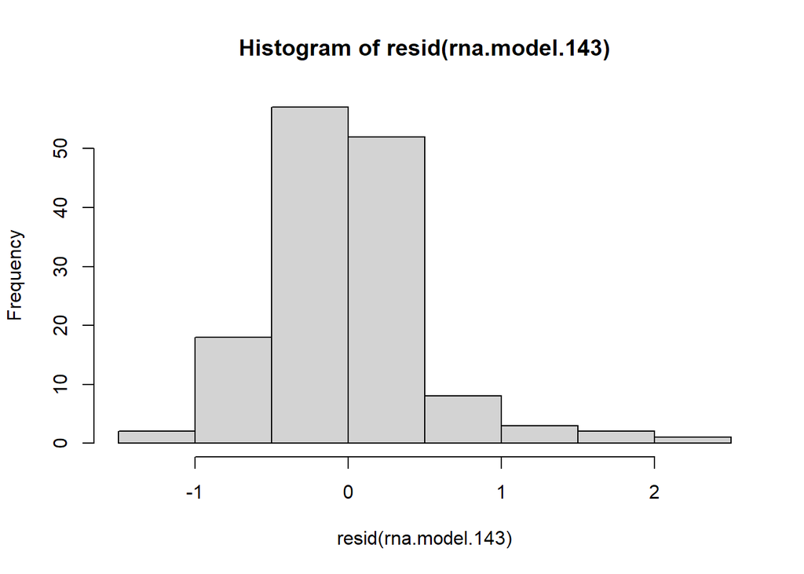

```r
hist(resid(rna.model.143))
```

```r
shapiro.test(resid(rna.model.143))$p.value
```

```
## [1] 4.278782e-07
```

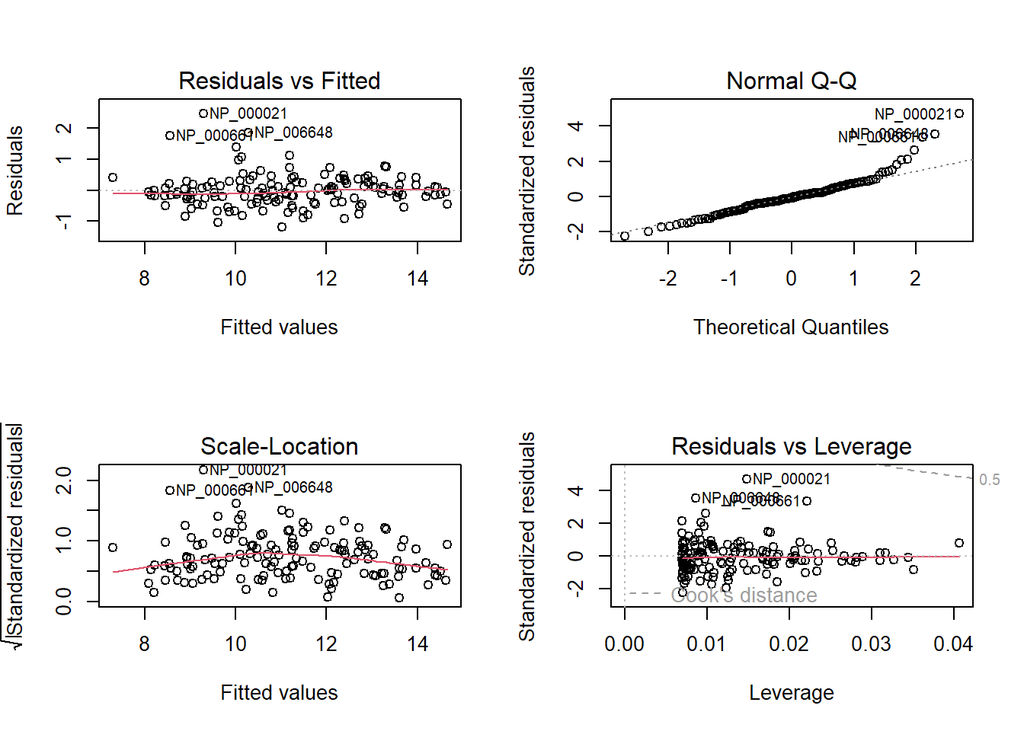

```r
par(mfrow=c(2,2))
plot(rna.model.143)
```

```r
anova(rna.model.143)
```

```
## Analysis of Variance Table
##
## Response: df.143$human.rna
##                   Df Sum Sq Mean Sq F value    Pr(>F)
## df.143$chimp.rna   1 439.73  439.73  1569.4 < 2.2e-16 ***
## Residuals        141  39.51    0.28
## ---
## Signif. codes:  0 '***' 0.001 '**' 0.01 '*' 0.05 '.' 0.1 ' ' 1
```

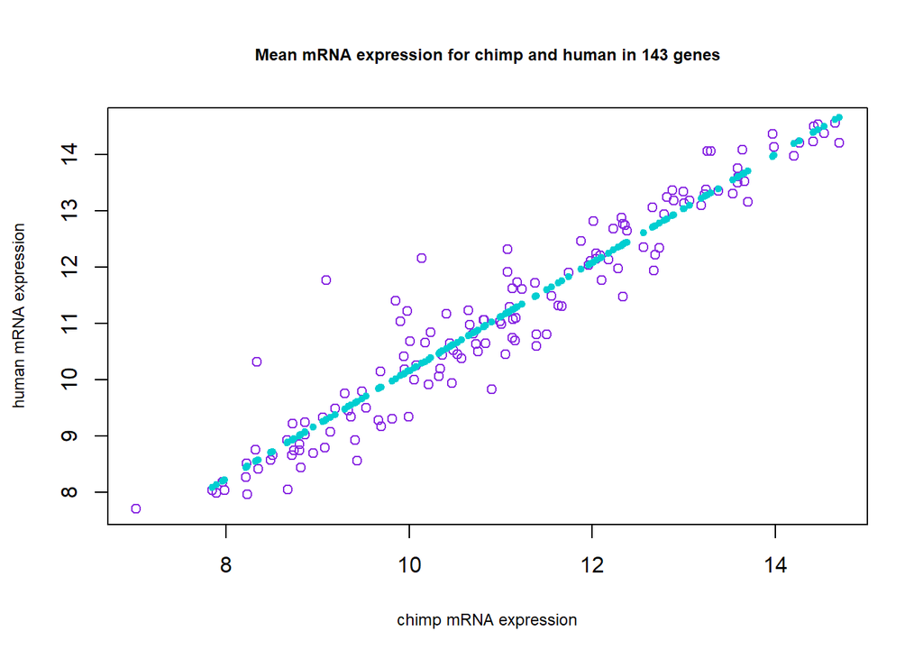

```r
par(mfrow=c(1,1))
plot(df.143$chimp.rna,df.143$human.rna,xlab="chimp mRNA expression",ylab="human mRNA expression",main="Mean mRNA expression for chimp and human in 143 genes",cex.lab=.75,cex.main=.75,col="blueviolet")
points(df.143$chimp.rna[!is.na(df.143$human.rna)],predict(rna.model.143),col="darkturquoise",pch=20)
```

```r
pr.model.143<-lm(df.143$human.pr~df.143$chimp.pr,df.143);pr.model.143
```

```
##
## Call:
## lm(formula = df.143$human.pr ~ df.143$chimp.pr, data = df.143)
##
## Coefficients:
##     (Intercept)  df.143$chimp.pr
##         0.02433         -0.44955
```

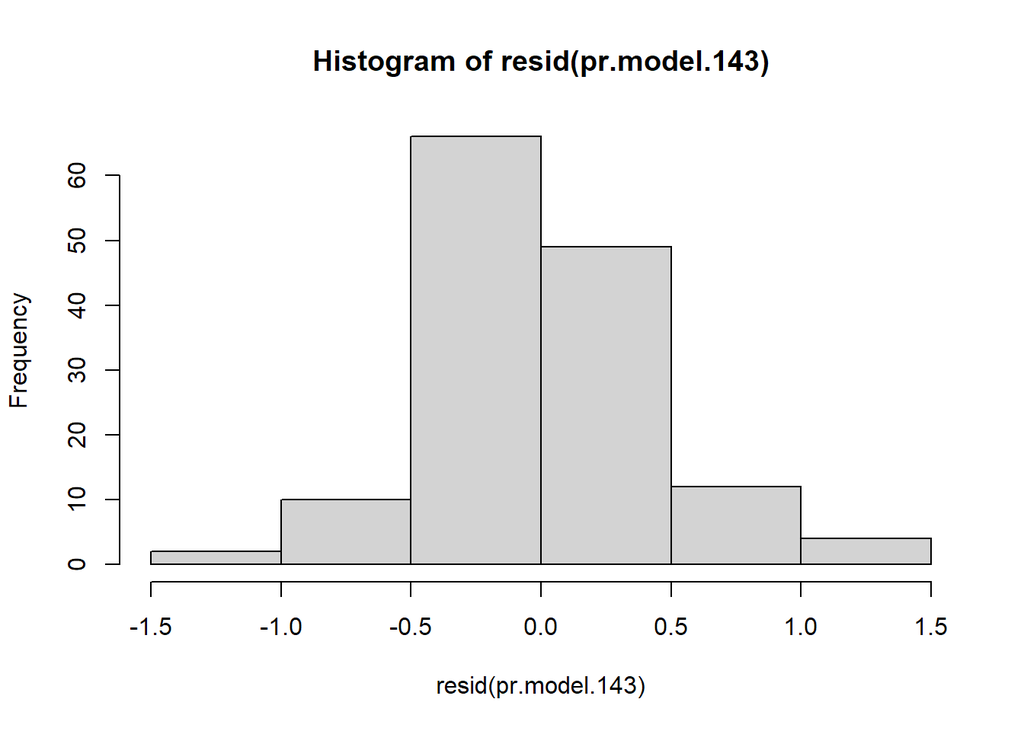

```r
hist(resid(pr.model.143))
```

```r
shapiro.test(resid(pr.model.143))$p.value
```

```
## [1] 0.0009737057
```

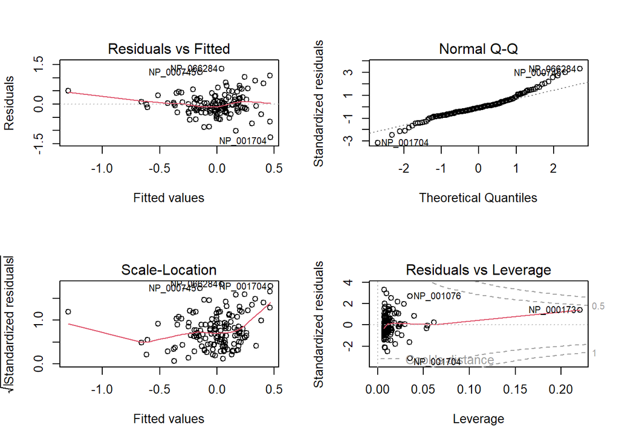

```r
par(mfrow=c(2,2))
plot(pr.model.143)
```

```r
anova(pr.model.143)
```

```
## Analysis of Variance Table
##
## Response: df.143$human.pr
##                  Df  Sum Sq Mean Sq F value    Pr(>F)
## df.143$chimp.pr   1  7.8552  7.8552  47.394 1.759e-10 ***
## Residuals       141 23.3694  0.1657
## ---
## Signif. codes:  0 '***' 0.001 '**' 0.01 '*' 0.05 '.' 0.1 ' ' 1
```

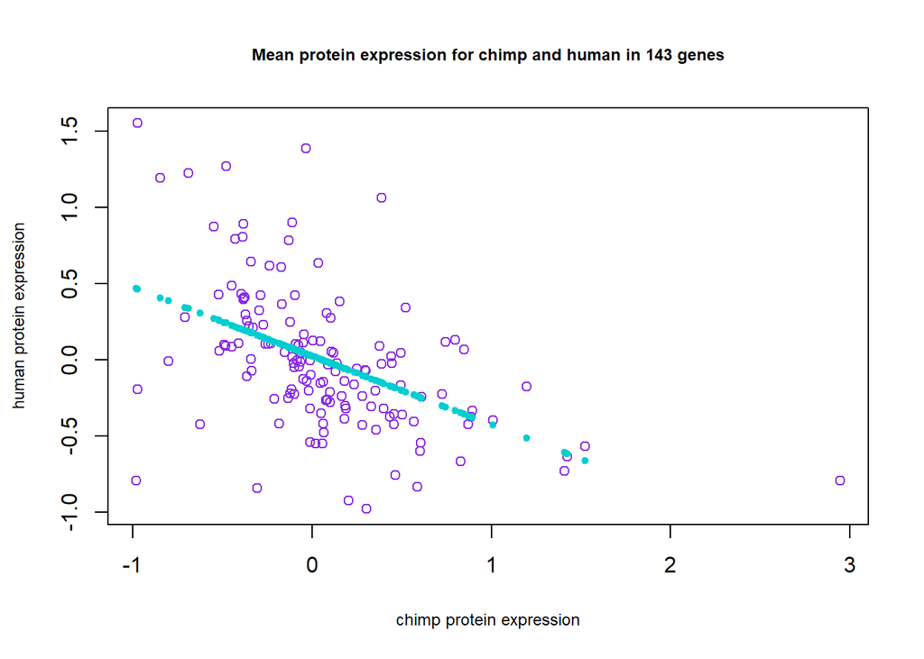

```r
par(mfrow=c(1,1))
plot(df.143$chimp.pr,df.143$human.pr,xlab="chimp protein expression",ylab="human protein expression",main="Mean protein expression for chimp and human in 143 genes",cex.lab=.75,cex.main=.75,col="blueviolet")
points(df.143$chimp.pr[!is.na(df.143$human.pr)],predict(pr.model.143),col="darkturquoise",pch=20)
```

```r
rna.model.159<-lm(df.159$human.rna~df.159$chimp.rna,df.159);rna.model.159
```

```
##
## Call:
## lm(formula = df.159$human.rna ~ df.159$chimp.rna, data = df.159)
##
## Coefficients:
##      (Intercept)  df.159$chimp.rna
##           0.7545            0.9469
```

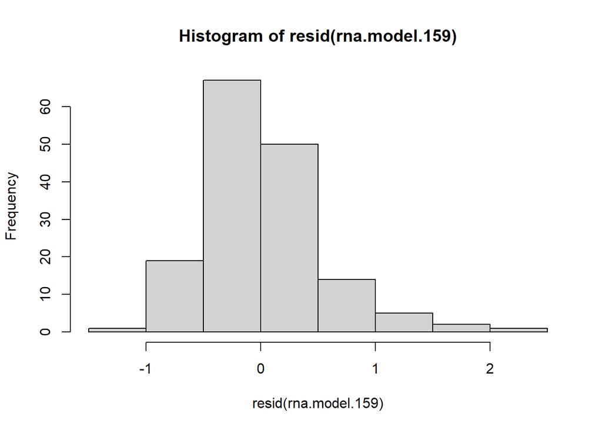

```r
hist(resid(rna.model.159))
```

```r
shapiro.test(resid(rna.model.159))$p.value
```

```
## [1] 2.42308e-06
```

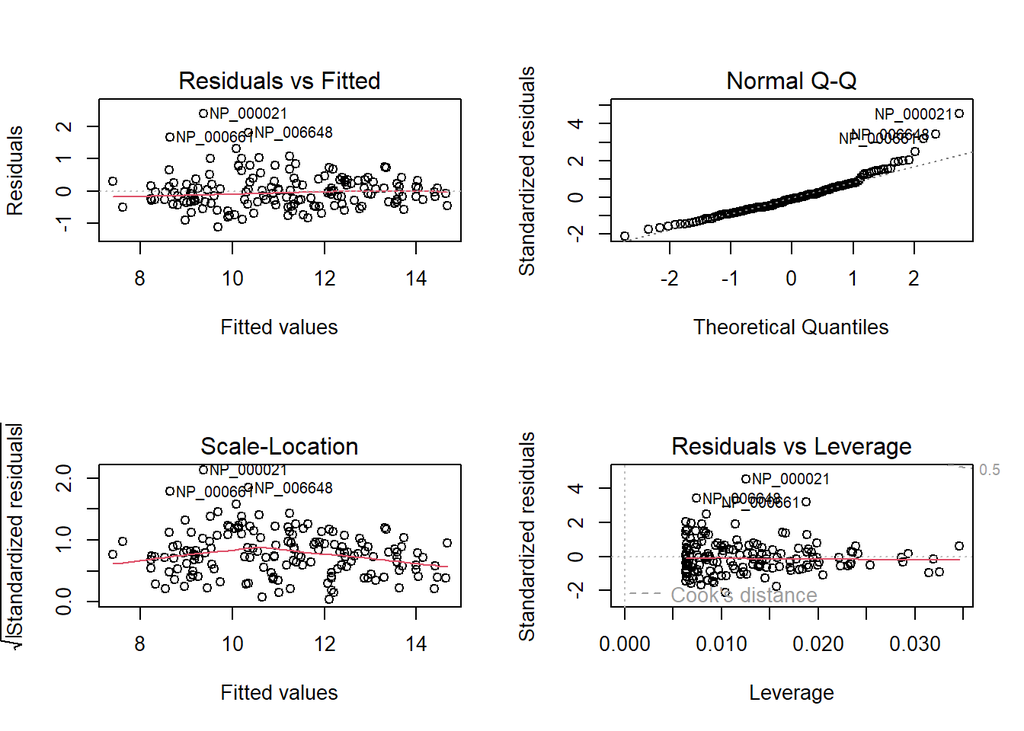

```r
par(mfrow=c(2,2))
plot(rna.model.159)
```

```r
anova(rna.model.159)
```

```
## Analysis of Variance Table
##
## Response: df.159$human.rna
##                   Df Sum Sq Mean Sq F value    Pr(>F)
## df.159$chimp.rna   1 484.70  484.70  1729.8 < 2.2e-16 ***
## Residuals        157  43.99    0.28
## ---
## Signif. codes:  0 '***' 0.001 '**' 0.01 '*' 0.05 '.' 0.1 ' ' 1
```

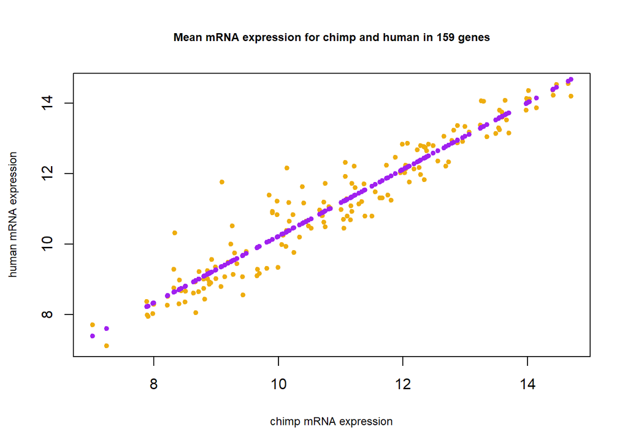

```r
par(mfrow=c(1,1))
plot(df.159$chimp.rna,df.159$human.rna,xlab="chimp mRNA expression",ylab="human mRNA expression",main="Mean mRNA expression for chimp and human in 159 genes",cex.lab=.75,cex.main=.75,col="darkgoldenrod2",pch=20)
points(df.159$chimp.rna[!is.na(df.159$human.rna)],predict(rna.model.159),col="purple",pch=20)
```

```r
pr.model.159<-lm(df.159$human.pr~df.159$chimp.pr,df.159);pr.model.159
```

```
##
## Call:
## lm(formula = df.159$human.pr ~ df.159$chimp.pr, data = df.159)
##
## Coefficients:
##     (Intercept)  df.159$chimp.pr
##          0.1281          -0.1908
```

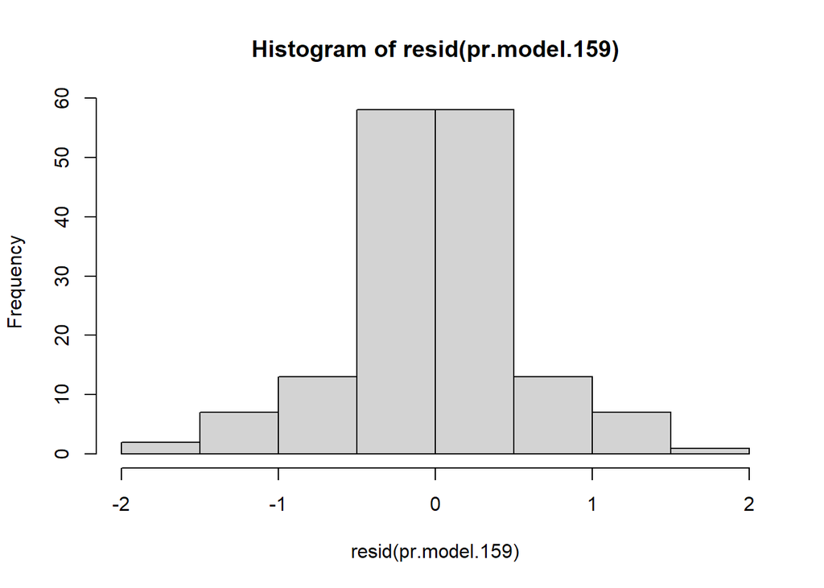

```r
hist(resid(pr.model.159))
```

```r
shapiro.test(resid(pr.model.159))$p.value
```

```
## [1] 0.003642212
```

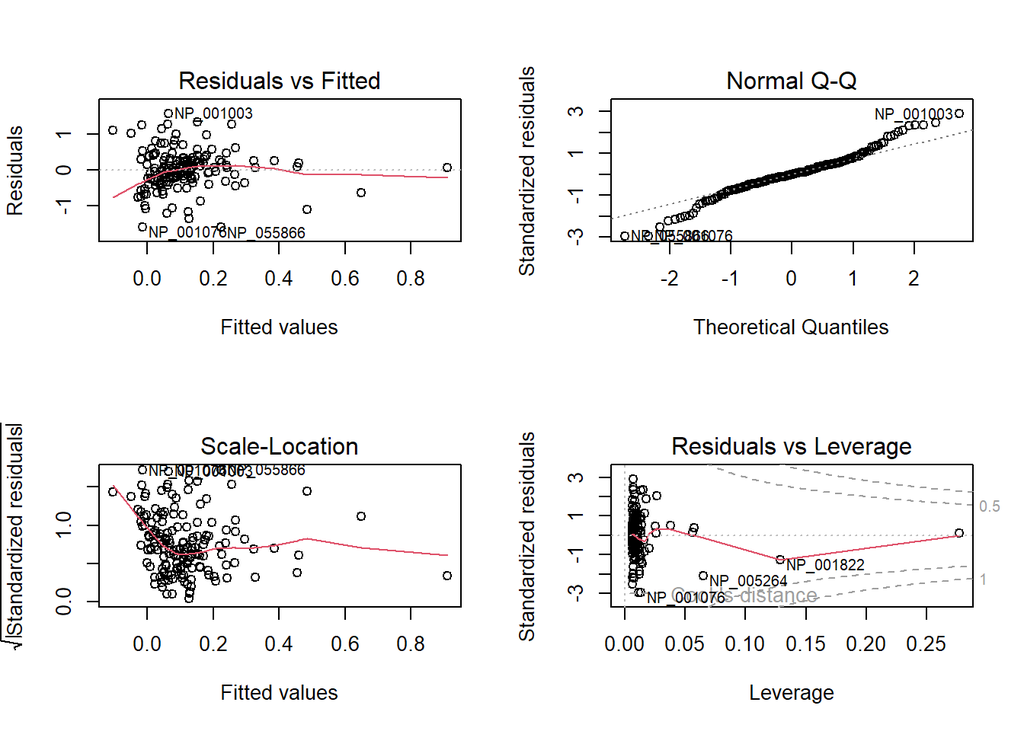

```r
par(mfrow=c(2,2))
plot(pr.model.159)
```

```r
anova(pr.model.159)
```

```
## Analysis of Variance Table
##
## Response: df.159$human.pr
##                  Df Sum Sq Mean Sq F value   Pr(>F)
## df.159$chimp.pr   1  2.356  2.3556  8.0642 0.005113 **
## Residuals       157 45.860  0.2921
## ---
## Signif. codes:  0 '***' 0.001 '**' 0.01 '*' 0.05 '.' 0.1 ' ' 1
```

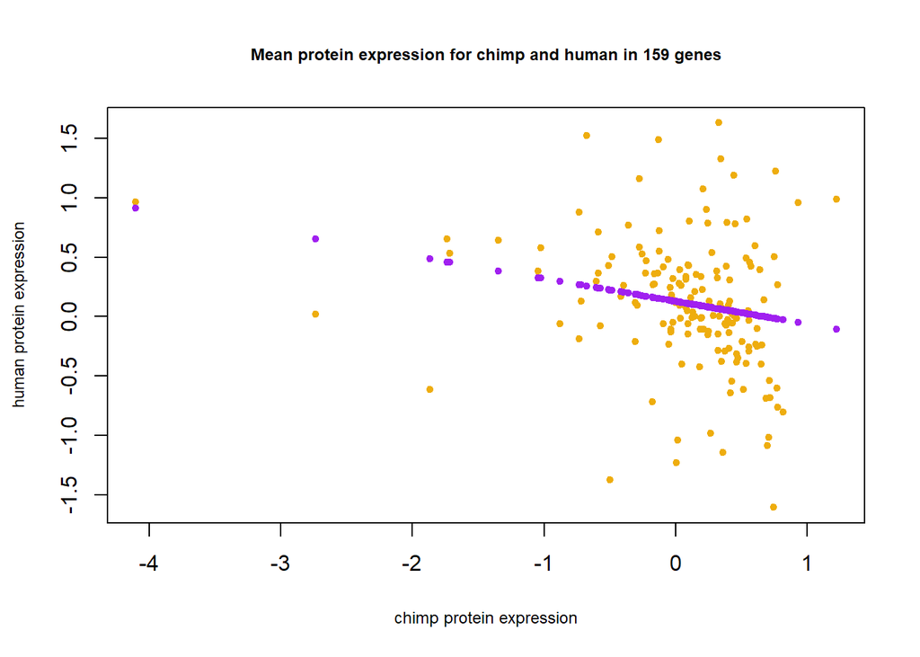

```r
par(mfrow=c(1,1))
plot(df.159$chimp.pr,df.159$human.pr,xlab="chimp protein expression",ylab="human protein expression",main="Mean protein expression for chimp and human in 159 genes",cex.lab=.75,cex.main=.75,col="darkgoldenrod2",pch=20)
points(df.159$chimp.pr[!is.na(df.159$human.pr)],predict(pr.model.159),col="purple",pch=20)
```

## Question 4

The following code plots the mean protein expression vs mean mRNA expression for chimp and for human, for each data set. Upon visual inspection of these plots, there does not appear to be much of a relationship between mRNA expression and protein expression in either species in either data set. The points are fairly uniformly distributed and it is difficult to envision a linear model line demonstrating a strong relationship between them.

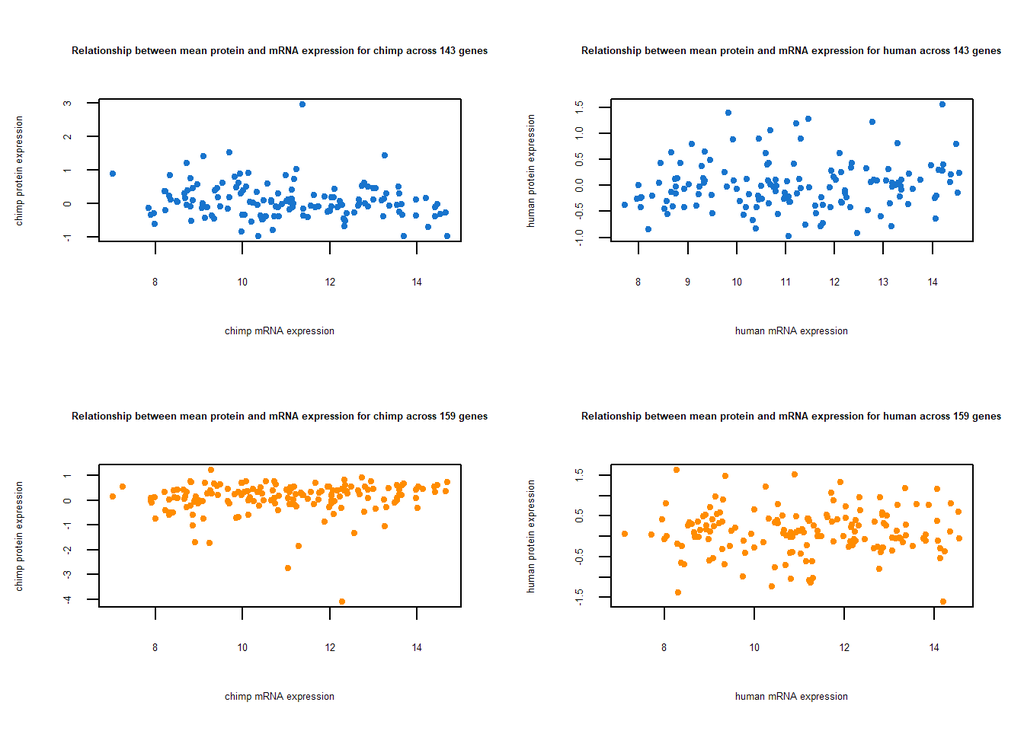

```r
par(mfrow=c(2,2))
plot(df.143$chimp.rna,df.143$chimp.pr,xlab="chimp mRNA expression",ylab="chimp protein expression",main="Relationship between mean protein and mRNA expression for chimp across 143 genes",cex.lab=.50,cex.main=.50,col="dodgerblue3",cex.axis=.5,pch=20)
plot(df.143$human.rna,df.143$human.pr,xlab="human mRNA expression",ylab="human protein expression",main="Relationship between mean protein and mRNA expression for human across 143 genes",cex.lab=.50,cex.main=.50,col="dodgerblue3",cex.axis=.5,pch=20)
plot(df.159$chimp.rna,df.159$chimp.pr,xlab="chimp mRNA expression",ylab="chimp protein expression",main="Relationship between mean protein and mRNA expression for chimp across 159 genes",cex.lab=.50,cex.main=.50,col="darkorange",cex.axis=.5,pch=20)
plot(df.159$human.rna,df.159$human.pr,xlab="human mRNA expression",ylab="human protein expression",main="Relationship between mean protein and mRNA expression for human across 159 genes",cex.lab=.50,cex.main=.50,col="darkorange",cex.axis=.5,pch=20)
```